# NLP with Naive Bayes Classifier

### Making the necessary imports

```python
import pandas as pd
import numpy as np
import nltk
import string
import re
import tqdm

from collections import Counter
import matplotlib.pyplot as plt
import seaborn as sns
sns.set()

#defining stopwords
from nltk.corpus import stopwords

from nltk.stem.porter import PorterStemmer
from nltk.tokenize import casual_tokenize

from sklearn.metrics import accuracy_score
from sklearn.metrics import confusion_matrix
from sklearn.metrics import classification_report, ConfusionMatrixDisplay
from sklearn.metrics import make_scorer, roc_curve, roc_auc_score
from sklearn.metrics import precision_recall_fscore_support as score
from sklearn.naive_bayes import GaussianNB, MultinomialNB
```

### Understanding the dataset

The dataset used in this blog is the news category dataset[1][2], available here: https://www.kaggle.com/datasets/rmisra/news-category-dataset. This dataset contains around 200,000 news headlines and descriptions, from various categories from the year 2012 to 2018 obtained from HuffPost. The dataset also includes attributes such as authors, date etc. Each news headline has a corresponding category, some of the categories are as follows - Politics, wellness, entertainment, travel, parenting etc. Here's a sample of the dataset.

```python
df = pd.read_json('../input/news-category-dataset/News_Category_Dataset_v2.json',lines=True)
df
```

|  | category | headline | authors | link | short_description | date |
| --- | --- | --- | --- | --- | --- | --- |
| 0 | CRIME | There Were 2 Mass Shootings In Texas Last Week... | Melissa Jeltsen | https://www.huffingtonpost.com/entry/texas-ama... | She left her husband. He killed their children... | 2018-05-26 |
| 1 | ENTERTAINMENT | Will Smith Joins Diplo And Nicky Jam For The 2... | Andy McDonald | https://www.huffingtonpost.com/entry/will-smit... | Of course it has a song. | 2018-05-26 |
| 2 | ENTERTAINMENT | Hugh Grant Marries For The First Time At Age 57 | Ron Dicker | https://www.huffingtonpost.com/entry/hugh-gran... | The actor and his longtime girlfriend Anna Ebe... | 2018-05-26 |
| 3 | ENTERTAINMENT | Jim Carrey Blasts 'Castrato' Adam Schiff And D... | Ron Dicker | https://www.huffingtonpost.com/entry/jim-carre... | The actor gives Dems an ass-kicking for not fi... | 2018-05-26 |
| 4 | ENTERTAINMENT | Julianna Margulies Uses Donald Trump Poop Bags... | Ron Dicker | https://www.huffingtonpost.com/entry/julianna-... | The "Dietland" actress said using the bags is ... | 2018-05-26 |
| ... | ... | ... | ... | ... | ... | ... |
| 200848 | TECH | RIM CEO Thorsten Heins' 'Significant' Plans Fo... | Reuters, Reuters | https://www.huffingtonpost.com/entry/rim-ceo-t... | Verizon Wireless and AT&T are already promotin... | 2012-01-28 |
| 200849 | SPORTS | Maria Sharapova Stunned By Victoria Azarenka I... |  | https://www.huffingtonpost.com/entry/maria-sha... | Afterward, Azarenka, more effusive with the pr... | 2012-01-28 |
| 200850 | SPORTS | Giants Over Patriots, Jets Over Colts Among M... |  | https://www.huffingtonpost.com/entry/super-bow... | Leading up to Super Bowl XLVI, the most talked... | 2012-01-28 |
| 200851 | SPORTS | Aldon Smith Arrested: 49ers Linebacker Busted ... |  | https://www.huffingtonpost.com/entry/aldon-smi... | CORRECTION: An earlier version of this story i... | 2012-01-28 |
| 200852 | SPORTS | Dwight Howard Rips Teammates After Magic Loss ... |  | https://www.huffingtonpost.com/entry/dwight-ho... | The five-time all-star center tore into his te... | 2012-01-28 |

200853 rows × 6 columns

We only need 2 columns, namely - category and headline. All the other columns can be dropped.

```python
df.drop(columns=['authors','link','date','short_description'],inplace=True)
df
```

|  | category | headline |
| --- | --- | --- |
| 0 | CRIME | There Were 2 Mass Shootings In Texas Last Week... |
| 1 | ENTERTAINMENT | Will Smith Joins Diplo And Nicky Jam For The 2... |
| 2 | ENTERTAINMENT | Hugh Grant Marries For The First Time At Age 57 |
| 3 | ENTERTAINMENT | Jim Carrey Blasts 'Castrato' Adam Schiff And D... |
| 4 | ENTERTAINMENT | Julianna Margulies Uses Donald Trump Poop Bags... |
| ... | ... | ... |
| 200848 | TECH | RIM CEO Thorsten Heins' 'Significant' Plans Fo... |
| 200849 | SPORTS | Maria Sharapova Stunned By Victoria Azarenka I... |
| 200850 | SPORTS | Giants Over Patriots, Jets Over Colts Among M... |
| 200851 | SPORTS | Aldon Smith Arrested: 49ers Linebacker Busted ... |
| 200852 | SPORTS | Dwight Howard Rips Teammates After Magic Loss ... |

200853 rows × 2 columns

```python
df['category'].nunique()
```

```
41
```

The dataset has a total of 41 unique categories. The headlines are scattered over these categories (with some imbalance present among the number of headlines per category)

```python
df_g = df.groupby('category').count()
df_g
```

| category | headline |
| --- | --- |
| ARTS | 1509 |
| ARTS & CULTURE | 1339 |
| BLACK VOICES | 4528 |
| BUSINESS | 5937 |
| COLLEGE | 1144 |
| COMEDY | 5175 |
| CRIME | 3405 |
| CULTURE & ARTS | 1030 |
| DIVORCE | 3426 |
| EDUCATION | 1004 |
| ENTERTAINMENT | 16058 |
| ENVIRONMENT | 1323 |
| FIFTY | 1401 |
| FOOD & DRINK | 6226 |
| GOOD NEWS | 1398 |
| GREEN | 2622 |
| HEALTHY LIVING | 6694 |
| HOME & LIVING | 4195 |
| IMPACT | 3459 |
| LATINO VOICES | 1129 |
| MEDIA | 2815 |
| MONEY | 1707 |
| PARENTING | 8677 |
| PARENTS | 3955 |
| POLITICS | 32739 |
| QUEER VOICES | 6314 |
| RELIGION | 2556 |
| SCIENCE | 2178 |
| SPORTS | 4884 |
| STYLE | 2254 |
| STYLE & BEAUTY | 9649 |
| TASTE | 2096 |
| TECH | 2082 |
| THE WORLDPOST | 3664 |
| TRAVEL | 9887 |
| WEDDINGS | 3651 |
| WEIRD NEWS | 2670 |
| WELLNESS | 17827 |
| WOMEN | 3490 |
| WORLD NEWS | 2177 |
| WORLDPOST | 2579 |

```python
categories = df['category'].unique()
print(categories)
```

```
['CRIME' 'ENTERTAINMENT' 'WORLD NEWS' 'IMPACT' 'POLITICS' 'WEIRD NEWS'
 'BLACK VOICES' 'WOMEN' 'COMEDY' 'QUEER VOICES' 'SPORTS' 'BUSINESS'
 'TRAVEL' 'MEDIA' 'TECH' 'RELIGION' 'SCIENCE' 'LATINO VOICES' 'EDUCATION'
 'COLLEGE' 'PARENTS' 'ARTS & CULTURE' 'STYLE' 'GREEN' 'TASTE'
 'HEALTHY LIVING' 'THE WORLDPOST' 'GOOD NEWS' 'WORLDPOST' 'FIFTY' 'ARTS'
 'WELLNESS' 'PARENTING' 'HOME & LIVING' 'STYLE & BEAUTY' 'DIVORCE'
 'WEDDINGS' 'FOOD & DRINK' 'MONEY' 'ENVIRONMENT' 'CULTURE & ARTS']
```

Text labels might become problematic in the future, let's convert these to integer labels.

```python
# convert to numeric ID
df['label'] = df['category'].factorize()[0]
df.head()
```

|  | category | headline | label |
| --- | --- | --- | --- |
| 0 | CRIME | There Were 2 Mass Shootings In Texas Last Week... | 0 |
| 1 | ENTERTAINMENT | Will Smith Joins Diplo And Nicky Jam For The 2... | 1 |
| 2 | ENTERTAINMENT | Hugh Grant Marries For The First Time At Age 57 | 1 |
| 3 | ENTERTAINMENT | Jim Carrey Blasts 'Castrato' Adam Schiff And D... | 1 |
| 4 | ENTERTAINMENT | Julianna Margulies Uses Donald Trump Poop Bags... | 1 |

```python
categories = df[['category', 'label']].drop_duplicates().sort_values('label')
```

```python
categories
```

|  | category | label |
| --- | --- | --- |
| 0 | CRIME | 0 |
| 1 | ENTERTAINMENT | 1 |
| 11 | WORLD NEWS | 2 |
| 12 | IMPACT | 3 |
| 13 | POLITICS | 4 |
| 20 | WEIRD NEWS | 5 |
| 27 | BLACK VOICES | 6 |
| 35 | WOMEN | 7 |
| 37 | COMEDY | 8 |
| 69 | QUEER VOICES | 9 |
| 80 | SPORTS | 10 |
| 87 | BUSINESS | 11 |
| 126 | TRAVEL | 12 |
| 127 | MEDIA | 13 |
| 137 | TECH | 14 |
| 146 | RELIGION | 15 |
| 155 | SCIENCE | 16 |
| 258 | LATINO VOICES | 17 |
| 443 | EDUCATION | 18 |
| 6109 | COLLEGE | 19 |
| 6194 | PARENTS | 20 |
| 6715 | ARTS & CULTURE | 21 |
| 7293 | STYLE | 22 |
| 7407 | GREEN | 23 |
| 7499 | TASTE | 24 |
| 7578 | HEALTHY LIVING | 25 |
| 14228 | THE WORLDPOST | 26 |
| 19359 | GOOD NEWS | 27 |
| 34622 | WORLDPOST | 28 |
| 35278 | FIFTY | 29 |
| 36003 | ARTS | 30 |
| 124989 | WELLNESS | 31 |
| 124992 | PARENTING | 32 |
| 125000 | HOME & LIVING | 33 |
| 125004 | STYLE & BEAUTY | 34 |
| 125009 | DIVORCE | 35 |
| 125013 | WEDDINGS | 36 |
| 125019 | FOOD & DRINK | 37 |
| 125035 | MONEY | 38 |
| 125421 | ENVIRONMENT | 39 |
| 125440 | CULTURE & ARTS | 40 |

```python
df_g = df.groupby('category').count()
```

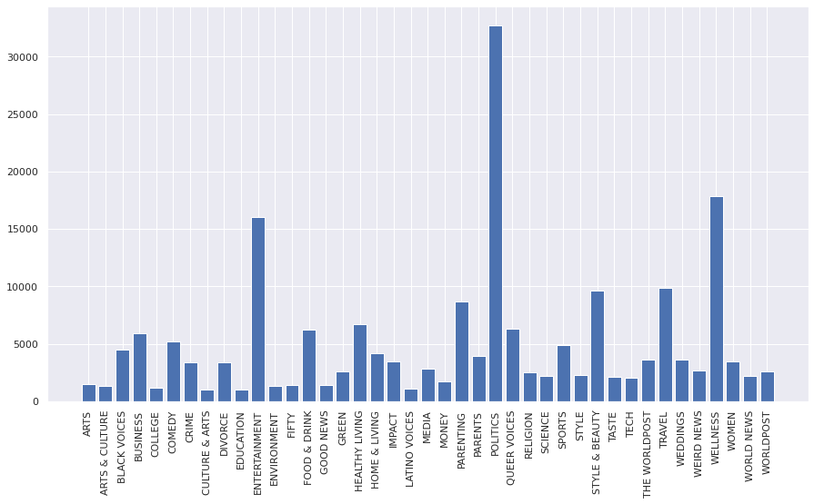

```python
fig = plt.figure(figsize=(15,8))
plt.bar(df_g.index,df_g['headline'])
plt.xticks(rotation=90)
plt.show()
```

There are a high number of headlines present for Politics, Wellness and Entertainment as compared to other categories. This class imbalance might affect our classifier. However, we'll proceed with the same distribution, though we might have to reduce the number of examples we use to prevent long computations.

### Preprocessing the dataset

Natural Language data cannot be used directly while training a machine learning model. ML models understand the language of vectors and numbers; english, not so much. While preprocessing the data, we will perform several operations such as removing stopwords, tokenizing the data etc. in an attempt to minimize the number of features that the model trains on. Also, this way, the noise is minimized in the train set.

#### Stopwords

Stop words are a set of commonly used words in any language. Usually, removing these words doesn't have any negative impacts on our model, instead it serves to reduce the noise present in the dataset. Upon removing stopwords, the remaining words are those that have more impact on the model's classfication. To learn more about stopwords, please refer: https://kavita-ganesan.com/what-are-stop-words/.

Following are the stopwords that we will remove from our dataset. This set of stop words is obtained from the "natural language toolkit (nltk)" library.

```python
#stopwords
print(", ".join(stopwords.words('english')))
stops = set(stopwords.words('english'))
```

```
i, me, my, myself, we, our, ours, ourselves, you, you're, you've, you'll, you'd, your, yours, yourself, yourselves, he, him, his, himself, she, she's, her, hers, herself, it, it's, its, itself, they, them, their, theirs, themselves, what, which, who, whom, this, that, that'll, these, those, am, is, …
```

The dataset has more than 200000 examples and probably much more unique words. In order to prevent long computation times and prevent out of memory errors in kaggle, we'll take only 10000 samples from the dataset while keeping the current data distribution.

```python
df
```

|  | category | headline | label |
| --- | --- | --- | --- |
| 0 | CRIME | There Were 2 Mass Shootings In Texas Last Week... | 0 |
| 1 | ENTERTAINMENT | Will Smith Joins Diplo And Nicky Jam For The 2... | 1 |
| 2 | ENTERTAINMENT | Hugh Grant Marries For The First Time At Age 57 | 1 |
| 3 | ENTERTAINMENT | Jim Carrey Blasts 'Castrato' Adam Schiff And D... | 1 |
| 4 | ENTERTAINMENT | Julianna Margulies Uses Donald Trump Poop Bags... | 1 |
| ... | ... | ... | ... |
| 200848 | TECH | RIM CEO Thorsten Heins' 'Significant' Plans Fo... | 14 |
| 200849 | SPORTS | Maria Sharapova Stunned By Victoria Azarenka I... | 10 |
| 200850 | SPORTS | Giants Over Patriots, Jets Over Colts Among M... | 10 |
| 200851 | SPORTS | Aldon Smith Arrested: 49ers Linebacker Busted ... | 10 |
| 200852 | SPORTS | Dwight Howard Rips Teammates After Magic Loss ... | 10 |

200853 rows × 3 columns

```python
df1 = df.sample(frac=1).reset_index(drop=True)[:10000]
df1
```

|  | category | headline | label |
| --- | --- | --- | --- |
| 0 | CRIME | 786 CHILDREN DEAD: Abuse, Neglect Reportedly O... | 0 |
| 1 | FOOD & DRINK | The Ultimate Caesar Salad | 37 |
| 2 | SPORTS | Carli Lloyd Correctly Says She's The Best Play... | 10 |
| 3 | POLITICS | Jose Antonio Vargas Says His Detention At The ... | 4 |
| 4 | FIFTY | 17 Things You Should Never Say To A Friend Wit... | 29 |
| ... | ... | ... | ... |
| 9995 | ENTERTAINMENT | Taylor Swift Surprises 96-Year-Old Fan With At... | 1 |
| 9996 | BUSINESS | Bruce and Elisabeth Percelay - How to Make a D... | 11 |
| 9997 | QUEER VOICES | An Interview With A Gay, Russian Neo-Nazi | 9 |
| 9998 | BUSINESS | Want To Make A Difference? Don't Be A Hedge Fu... | 11 |
| 9999 | CRIME | Three Arrested With Cache Of Weapons, Some Loa... | 0 |

10000 rows × 3 columns

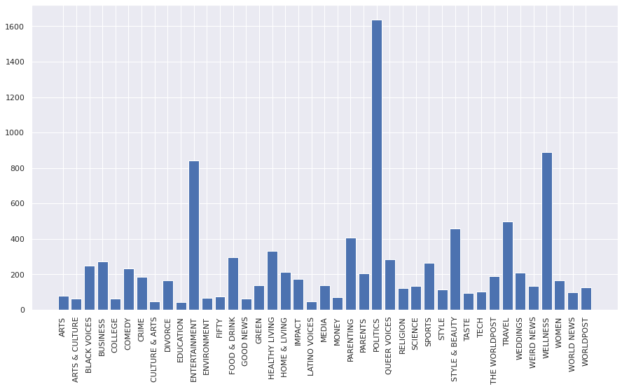

```python
df1g = df1.groupby('category').count()
fig = plt.figure(figsize=(15,8))
plt.bar(df1g.index,df1g['headline'])
plt.xticks(rotation=90)
plt.show()
```

As the first step in data preprocessing, we'll convert all text to lowercase and remove the stopwords. After this, we'll also remove any non-alphanumeric charater(other than whitespace). These steps will help normalize the dataset and also reduces the number of potential features that our classifier will have to work with.

```python
def preprocess(sent):
    sent = sent.lower() # make text lowercase
    sent = " ".join([word for word in str(sent).split() if word not in stops]) # removing stopwords
    sent = re.sub(r'[^A-Za-z0-9 ]+', '', sent) # removing non-alphanumeric characters and whitespaces (except " ")
    return sent
```

```python
df1['headline_prep'] = df1['headline'].apply(preprocess)
```

```python
df1['headline_prep']
```

```
0       786 children dead abuse neglect reportedly occ...
1                                   ultimate caesar salad
2            carli lloyd correctly says best player world
3         jose antonio vargas says detention border stunt
4                17 things never say friend breast cancer
                              ...
9995    taylor swift surprises 96yearold fan athome vi...
9996            bruce elisabeth percelay  make dent world
9997                        interview gay russian neonazi
9998              want make difference hedge fund manager
9999    three arrested cache weapons loaded near holla...
Name: headline_prep, Length: 10000, dtype: object
```

### Stemmization

The next step in preprocessing is to perform stemmization. The motivation behind stemmization is as follows: Sentences in english (and all other languages) sometimes use different forms of the same word, such as fly, flies, flying etc. There may also be some words that are derived from a base word and convey nearly the same meaning. It is useful for normalization and dimensionality reduction purposes to convert all these words to their base forms. This is what stemmization does for us. It reduces the inflectional forms and sometimes derivationally related forms of a word to a common base form.[3] For instance: car, cars, car's, cars' all become car.

However, note that stemmization may also result in loss of information sometimes. Stemmization and lemmatization reduce words to what these methods consider to be their base words. They may be wrong and reduce completely unrelated words to the same base word. Worse even, they may reduce words with opposite meanings to the same base word. "Normalization and stemming consolidate words into groups that improve the “recall” for search engines but reduce precision."[4]

```python
#Performing Stemmization (lemmatization is a good alternative)
stemmer = PorterStemmer()
def stem(sent):
    return " ".join([stemmer.stem(word) for word in sent.split()])

df1["headline_prep"] = df1["headline_prep"].apply(stem)
df1.head()
```

|  | category | headline | label | headline_prep |
| --- | --- | --- | --- | --- |
| 0 | CRIME | 786 CHILDREN DEAD: Abuse, Neglect Reportedly O... | 0 | 786 children dead abus neglect reportedli occu... |
| 1 | FOOD & DRINK | The Ultimate Caesar Salad | 37 | ultim caesar salad |
| 2 | SPORTS | Carli Lloyd Correctly Says She's The Best Play... | 10 | carli lloyd correctli say best player world |
| 3 | POLITICS | Jose Antonio Vargas Says His Detention At The ... | 4 | jose antonio varga say detent border stunt |
| 4 | FIFTY | 17 Things You Should Never Say To A Friend Wit... | 29 | 17 thing never say friend breast cancer |

Another operation we can apply to the dataset is removing the most frequent or least frequent words from the text. Usually there are words that get past the stopwords removal that don't provide any information but only act as noise for our classifier. Such words can often be found by looking at the most common words in the text; words such as message etc. We can also look at rarely used words.

```python
# removing words based on frequency
count = Counter()
for sent in df1["headline_prep"].to_numpy():
    for word in sent.split():
        count[word] += 1

count.most_common(10)
# the most common words might contain relevant information. Let's not remove them just yet
```

```
[('trump', 673),
 ('photo', 560),
 ('new', 414),
 ('video', 318),
 ('say', 298),
 ('day', 269),
 ('get', 262),
 ('make', 258),
 ('donald', 247),
 ('us', 243)]
```

Words like trump may be strong indicator of 'NEWS' category. We'll leave these words in for now.

Words that are rarely used in the dataset, unnecessarily increase the number of features. Such outliers can often be removed.

```python
rare_words = []
for word,freq in count.most_common():
    if(freq<=5):
        rare_words.append(word)
len(rare_words)
```

```
9240
```

```python
rare_words[:20]
```

```
['salad',
 'selena',
 'gomez',
 'tenni',
 'ray',
 'pasta',
 'argentina',
 'funer',
 'withdraw',
 'tori',
 'coverag',
 'emili',
 'dozen',
 'nighter',
 'royal',
 'j',
 'appli',
 'crap',
 'grandmoth',
 'bet']
```

```python
def remove_rarewords(sent):
    return " ".join([word for word in sent.split() if word not in rare_words])

df1["headline_prep"] = df1["headline_prep"].apply(remove_rarewords)
df1.head()
# might take some time
```

|  | category | headline | label | headline_prep |
| --- | --- | --- | --- | --- |
| 0 | CRIME | 786 CHILDREN DEAD: Abuse, Neglect Reportedly O... | 0 | children dead abus reportedli view author |
| 1 | FOOD & DRINK | The Ultimate Caesar Salad | 37 | ultim |
| 2 | SPORTS | Carli Lloyd Correctly Says She's The Best Play... | 10 | say best player world |
| 3 | POLITICS | Jose Antonio Vargas Says His Detention At The ... | 4 | antonio say border |
| 4 | FIFTY | 17 Things You Should Never Say To A Friend Wit... | 29 | 17 thing never say friend breast cancer |

#### Tokenization

Finally, once we are satisfied with the words we are leaving in the dataset, we can perform tokenization. Tokenization breaks down large bodies of texts into smaller more managable chunks. Tokens are the building block of a natural language. The tokens can be either words, subwords or characters. In our case, we will be focussing on word tokenization. Word Tokenization is performed on the entire corpus (text dataset) to obtain tokens. The tokens obtained are subsequently used to prepare a vocabulary. A vocabulary is the set of unique tokens in the corpus. We can construct the vocabulary by taking all the words in the text corpus or using only the k most frequently occuring words.[4]

```python
# creating a bag of words using nltk casual tokenizer
bow = []
for hline in df1.headline_prep:
    bow.append(Counter(casual_tokenize(hline)))
```

```python
bow[:5]
```

```
[Counter({'children': 1,
          'dead': 1,
          'abus': 1,
          'reportedli': 1,
          'view': 1,
          'author': 1}),
 Counter({'ultim': 1}),
 Counter({'say': 1, 'best': 1, 'player': 1, 'world': 1}),
 Counter({'antonio': 1, 'say': 1, 'border': 1}),
 Counter({'17': 1,
          'thing': 1,
          'never': 1,
          'say': 1,
          'friend': 1,
          'breast': 1,
          'cancer': 1})]
```

bow or "bag of words" is a list of unique tokens and their counts observed in each headline.

We can build the entire vocabulary and subsequently a dataframe using the bag of words. The df_bow dataframe consists of unique tokens as features and the values 0 or 1 indicating whether a headline has them. Thus our dataset is converted into a form we can use for training a classifier.

```python
df_bow = pd.DataFrame.from_records(bow)
df_bow.fillna(0.0,inplace=True) # filling nans with 0
```

```python
df_bow.head()
```

|  | children | dead | abus | reportedli | view | author | ultim | say | best | player | ... | agre | privaci | vulner | brilliant | wit | banana | bryan | teenag | bathroom | hacker |
| --- | --- | --- | --- | --- | --- | --- | --- | --- | --- | --- | --- | --- | --- | --- | --- | --- | --- | --- | --- | --- | --- |
| 0 | 1.0 | 1.0 | 1.0 | 1.0 | 1.0 | 1.0 | 0.0 | 0.0 | 0.0 | 0.0 | ... | 0.0 | 0.0 | 0.0 | 0.0 | 0.0 | 0.0 | 0.0 | 0.0 | 0.0 | 0.0 |
| 1 | 0.0 | 0.0 | 0.0 | 0.0 | 0.0 | 0.0 | 1.0 | 0.0 | 0.0 | 0.0 | ... | 0.0 | 0.0 | 0.0 | 0.0 | 0.0 | 0.0 | 0.0 | 0.0 | 0.0 | 0.0 |
| 2 | 0.0 | 0.0 | 0.0 | 0.0 | 0.0 | 0.0 | 0.0 | 1.0 | 1.0 | 1.0 | ... | 0.0 | 0.0 | 0.0 | 0.0 | 0.0 | 0.0 | 0.0 | 0.0 | 0.0 | 0.0 |
| 3 | 0.0 | 0.0 | 0.0 | 0.0 | 0.0 | 0.0 | 0.0 | 1.0 | 0.0 | 0.0 | ... | 0.0 | 0.0 | 0.0 | 0.0 | 0.0 | 0.0 | 0.0 | 0.0 | 0.0 | 0.0 |
| 4 | 0.0 | 0.0 | 0.0 | 0.0 | 0.0 | 0.0 | 0.0 | 1.0 | 0.0 | 0.0 | ... | 0.0 | 0.0 | 0.0 | 0.0 | 0.0 | 0.0 | 0.0 | 0.0 | 0.0 | 0.0 |

5 rows × 2350 columns

```python
df_bow['label'] = df1['label']
```

```python
from sklearn.model_selection import train_test_split
x_train, x_test, y_train, y_test = train_test_split(df_bow.drop(columns=['label']).to_numpy(),df_bow['label'].to_numpy(),test_size=0.3,random_state=42)
```

### Simple Naive Bayes

The Naive Bayes Classifiers (NBC) relatively simple but effective machine learning algorithms. They are based on the concept of conditional probability and Bayes's Theorem. There are several categories of Naive Bayes classifiers such as Gaussian NB, Multinomial NB, Disccrete NB, Categorical NB etc.

When the outcome of an event is based on the occurence of one or more events, conditional probability comes into the picture. here, we try to calculate the probability of the second event (say event B) given that the first event (say event A) has already happened. If the probability of the event changes when we consider the probability of the first event, we can say that the probability of event B is dependent of the occurrence of event A. This is denoted by P(B|A).

Simple Naive Bayes employs Bayes Theorem : P(A|B) = P(B|A)* P(A)/P(B) to determine the maximum probability of a feature vector belonging to some class.

```python
num_samples = len(x_train)
num_features = len(x_train[0])
samples_per_class = df_bow.label.value_counts().to_dict()
num_classes = len(np.unique(y_train))
```

```python
def naivebayescls(x_t):

    probs = np.empty(shape=num_classes)
    alpha = 10
    for y in range(num_classes):
        prob = samples_per_class[y]/num_samples # p(y)

        X = df_bow[df_bow.label == y].drop(columns='label').to_numpy()
        xt1 = x_t.copy()
        for x_f in X:
            x_t += x_f
        x_t -= xt1
        x_t += alpha
        x_t /= float(num_samples + alpha*num_features)
        probs[y] = np.prod(x_t)

    return np.argmax(probs)
```

```python
y_pred = []
for x_t in tqdm.tqdm(x_test):
    y_pred.append(naivebayescls(x_t))

accuracy = round(accuracy_score(y_test, y_pred) * 100, 2)
precision, recall, f1score, support = score(y_test, y_pred,average='macro')
print(f'Test Accuracy Score of GNB (scratch): % {accuracy}')
print(f'Precision : {precision}')
print(f'Recall : {recall}')
print(f'F1-score : {f1score}')
```

```
Test Accuracy Score of GNB (scratch): % 1.97
Precision : 0.00047967479674796744
Recall : 0.024390243902439025
F1-score : 0.0009408462832585173
```

### Gaussian Naive Bayes

We'll implement a Gaussian Naive Bayes classifier from scratch. The Gaussian Naive Bayes makes use of the following equation -  
$ P(x_i \mid y) = \frac{1}{\sqrt{2\pi\sigma^2_y}} \exp\left(-\frac{(x_i - \mu_y)^2}{2\sigma^2_y}\right) $

The parameters variance and mean are estimated using maximum likelihood. Following is an implementation of Gaussian Naive Bayes from scratch.

```python
# Ref : https://medium.com/swlh/naive-bayes-from-scratch-c0c93ed4b826
class GaussianNaiveBayes:

    def fit(self, X, y):
        n_samples, n_features = X.shape
        self.classes = np.unique(y)
        n_classes = len(self.classes)

        # initialize mean, var, and prior
        self._mean = np.zeros((n_classes, n_features), dtype=np.float64)
        self._var = np.zeros((n_classes, n_features), dtype=np.float64)
        self._priors =  np.zeros(n_classes, dtype=np.float64)

        #calculate for each class
        for idx, c in enumerate(self.classes):
            X_c = X[y==c] #examples where label == c
            self._mean[idx, :] = X_c.mean(axis=0)
            self._var[idx, :] = X_c.var(axis=0)
            self._priors[idx] = X_c.shape[0] / float(n_samples) #P['the'] = num of documents containing ‘the’ / num of all documents

    def predict(self, X):
        y_pred = [self._predict(x) for x in X]
        return np.array(y_pred)

    def _predict(self, x):
        posteriors = []

        # calculate posterior probability for each class
        for idx, c in enumerate(self.classes):
            prior = np.log(self._priors[idx])
            posterior = np.sum(np.log(self._pdf(idx, x)))
            posterior = prior + posterior
            posteriors.append(posterior)

        # return class with highest posterior probability
        return self._classes[np.argmax(posteriors)]


    def _pdf(self, class_idx, x):
        mean = self._mean[class_idx]
        var = self._var[class_idx]
        numerator = np.exp((x - mean)**2 / -(2 * var))
        denominator = np.sqrt(2 * np.pi * var)
        return numerator / float(denominator)
```

```python
nb = GaussianNaiveBayes()
nb.fit(x_train, y_train)
y_pred = nb.predict(x_test)

accuracy = round(accuracy_score(y_test, y_pred) * 100, 2)
precision, recall, f1score, support = score(y_test, y_pred,average='macro')
print(f'Test Accuracy Score of GNB (scratch): % {accuracy}')
print(f'Precision : {precision}')
print(f'Recall : {recall}')
print(f'F1-score : {f1score}')
```

[output not shown]

### Gaussian Naive Bayes with epsilon smoothing

```python
class NaiveBayes:

    def fit(self, X, y):
        n_samples, n_features = X.shape
        self._classes = np.unique(y)
        n_classes = len(self._classes)
        self.eps = 1e-8 * np.var(X, axis=0).max() # defining the epsilon
        # calculate mean, var, and prior for each class
        self._mean = np.zeros((n_classes, n_features), dtype=np.float64)
        self._var = np.zeros((n_classes, n_features), dtype=np.float64)
        self._priors =  np.zeros(n_classes, dtype=np.float64)

        for idx, c in enumerate(self._classes):
            X_c = X[y==c]
            self._mean[idx, :] = X_c.mean(axis=0)
            self._var[idx, :] = X_c.var(axis=0)
            self._priors[idx] = X_c.shape[0]/float(n_samples)
        self._var[:,:] += self.eps # adding epsilon to prevent variance from causing divide by 0

    def predict(self, X):
        y_pred = [self._predict(x) for x in X]
        return np.array(y_pred)

    def _predict(self, x):
        posteriors = []

        # calculate posterior probability for each class
        for idx, c in enumerate(self._classes):
            prior = np.log(self._priors[idx])
            posterior = np.sum(np.log(self._pdf(idx, x)))
            posterior = prior + posterior
            posteriors.append(posterior)

        # return class with highest posterior probability
        return self._classes[np.argmax(posteriors)]


    def _pdf(self, class_idx, x):
        mean = self._mean[class_idx]
        var = self._var[class_idx]
        numerator = np.exp((x - mean)**2 / -(2 * var))
        denominator = np.sqrt(2 * np.pi * var)
        return numerator # removing denominator (our goal is only to get the class not the probabilities)
```

```python
nb = NaiveBayes()
nb.fit(x_train, y_train)
y_pred = nb.predict(x_test)

accuracy = round(accuracy_score(y_test, predictions) * 100, 2)
precision, recall, f1score, support = score(y_test, predictions,average='macro')
print(f'Test Accuracy Score of GNB (scratch)(with epsilon smoothing): % {accuracy}')
print(f'Precision : {precision}')
print(f'Recall : {recall}')
print(f'F1-score : {f1score}')
```

[output not shown]

```python
fig, ax = plt.subplots(figsize=(20,20))

disp = ConfusionMatrixDisplay.from_predictions(y_test,y_pred,ax=ax)
plt.grid(False)
plt.show()
```

[output not shown]

### Gaussian NB from sklearn

```python
gnb = GaussianNB()
gnb.fit(x_train,y_train)
y_pred = gnb.predict(x_test)
accuracy = round(accuracy_score(y_test, y_pred) * 100, 2)

# Get precision, recall, f1 scores

precision, recall, f1score, support = score(y_test, y_pred,average='macro')
print(f'Test Accuracy Score of GNB: % {accuracy}')
print(f'Precision : {precision}')
print(f'Recall : {recall}')
print(f'F1-score : {f1score}')
```

[output not shown]

```python
mnb = MultinomialNB()
mnb.fit(x_train,y_train)
y_pred = mnb.predict(x_test)
accuracy = round(accuracy_score(y_test, y_pred) * 100, 2)

# Get precision, recall, f1 scores

precision, recall, f1score, support = score(y_test, y_pred,average='macro')
print(f'Test Accuracy Score of MNB : % {accuracy}')
print(f'Precision : {precision}')
print(f'Recall : {recall}')
print(f'F1-score : {f1score}')
```

[output not shown]

### References

[1] Misra, R. και Grover, J. (01 2021) Sculpting Data for ML: The first act of Machine Learning.

[2] Misra, R. (06 2018) ‘News Category Dataset’. doi: 10.13140/RG.2.2.20331.18729.

[3] Manning, C. D., Raghavan, P., & Schütze, H. (2018). Introduction to information retrieval. Cambridge University Press.

[4] Lane, H., Howard, C. and Hapke, H., 2019. Natural Language Processing in Action. Manning.

[5] Pedregosa, F. κ.ά. (2011) ‘Scikit-learn: Machine Learning in Python’, Journal of Machine Learning Research, 12, σσ. 2825–2830.